# SOL-USD

## SOL-USD today is +0300, 2025-06-14, 06:39:27

This crypto forecast was generated by gemini-2.0-flash API

## Daily Chart

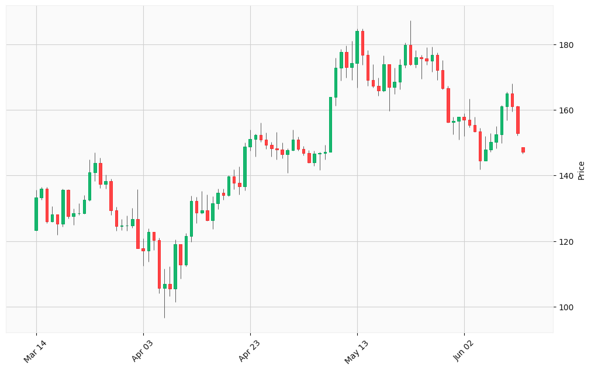

## Hourly Chart

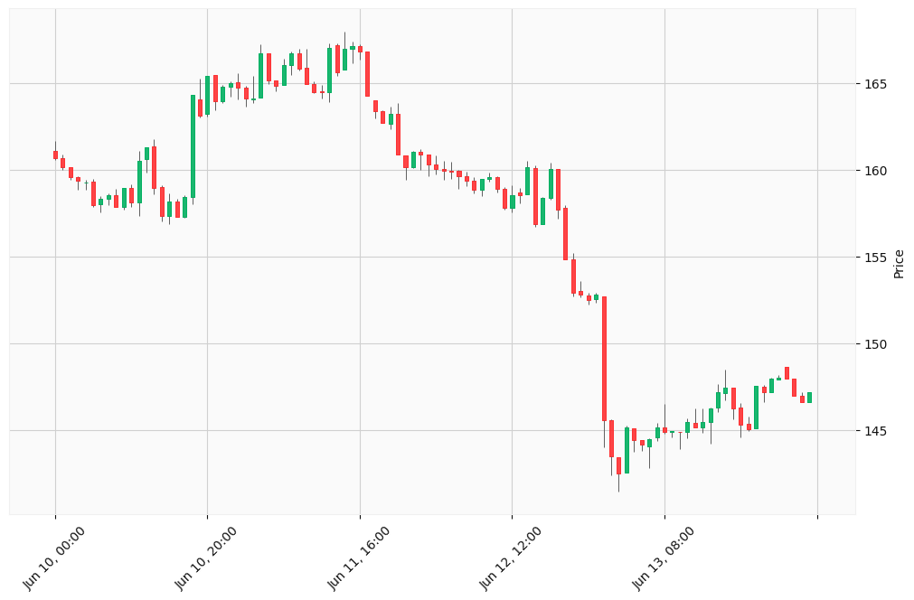

Okay, I will analyze the provided SOL-USD (Solana) OHLCV data, incorporating technical indicators, market trends, recent news, and economic factors to generate buy and sell signals. I will use both the daily chart (3 months, 1-day interval) and the hourly chart (5 days, 1-hour interval) to provide a comprehensive analysis.

Here’s my analysis and the generated trading signals:

**1. Market Data Collection:**

I will use the provided data and supplement it with real-time news and sentiment analysis from the web.

**2. Technical Analysis (Daily Chart):**

- **Moving Averages:** I’ll calculate the 50-day and 200-day Simple Moving Averages (SMA) from the provided data.
- **Relative Strength Index (RSI):** Calculate RSI (14-day period) to identify overbought or oversold conditions.
- **MACD:** Calculate MACD to identify potential trend changes.

**Python Code for Technical Indicators (Daily Chart):**

```python
import pandas as pd
import numpy as np

# Daily Chart Data
daily_data = """
123.287,135.643,123.117,133.314,3161542602
133.313,136.481,132.56,135.913,1844463215
135.917,136.469,125.387,125.988,2456569508
125.987,130.527,125.862,128.164,2487364373
128.161,128.161,121.945,125.313,2534317858
125.312,135.926,124.297,135.573,3539287974
135.574,135.773,126.854,127.497,2469659459
127.499,129.956,124.977,128.43,2370317364
128.43,131.576,127.933,128.485,1442831196
128.484,133.962,128.342,132.599,1711242607
132.599,144.883,132.162,140.869,4207560020
140.875,147.058,138.347,143.817,3585353324
143.817,145.368,136.136,137.289,3083070981
137.291,140.175,135.922,138.347,2660348034
138.347,138.953,127.981,129.423,3532896573
129.425,130.381,123.074,124.588,2253256988
124.586,126.623,123.301,124.643,1639017444
124.644,127.697,123.079,124.694,3206702485
124.695,130.032,123.949,126.682,2993289339
126.68,135.696,117.744,117.758,5399672438
117.749,120.79,112.478,117.061,4633002432
117.065,123.901,113.603,122.787,5182517335
122.786,122.787,117.189,120.259,1667996329
120.259,120.933,104.004,105.712,3822458629
105.712,111.472,96.5881,106.903,8644174246
106.905,112.299,103.145,105.512,5353641480
105.51,120.471,101.435,119.058,7096350476
119.062,119.083,108.602,112.804,4310698523
112.807,122.399,112.186,121.532,3953610468
121.533,133.759,119.659,132.261,4089397536
132.263,133.507,125.524,128.581,3818650340
128.578,135.187,128.233,129.31,4425565001
129.311,134.193,126.137,126.263,3272094237
126.263,133.59,123.721,131.45,4448562334
131.45,135.909,129.733,134.699,3504448606
134.704,135.869,132.588,134.074,2142264993
134.074,140.093,133.695,139.75,2522912658
139.753,141.83,135.771,137.775,2796023398
137.775,142.662,134.122,136.704,4162691832
136.702,149.949,135.378,148.739,4659792312
148.74,153.869,147.451,151.153,4699152180
151.154,152.754,145.661,152.304,3903057847
152.321,156.045,150.128,150.915,4411923686
150.917,153.02,148.037,149.289,2128235815
149.29,150.209,145.767,148.246,2015737709
148.245,153.208,144.891,147.81,3819502747
147.81,150.044,145.169,146.428,2872743502
146.427,148.209,140.712,147.643,3017472875
147.645,153.866,147.613,150.847,3224541533
150.843,151.732,147.452,148.05,2823970426
148.05,148.959,146.109,146.796,1567415096
146.796,147.683,143.822,143.983,1636835620
143.986,147.617,142.9,146.697,2238980623
146.696,147.09,141.671,146.766,2728680947
146.767,149.34,144.883,147.214,4316881378
147.217,163.975,147.214,163.961,6372889923
163.96,175.862,161.248,172.828,7452318987
172.828,178.572,168.929,177.622,4012477696
177.623,179.623,169.718,173.026,4025374577
173.037,180.951,169.078,174.248,6940951587
174.246,184.701,166.807,184.006,5170161208
184.006,184.718,173.732,176.709,4610872279
176.709,178.105,167.28,169.01,4347587992
169.015,173.958,166.757,167.334,3495576096
167.334,169.768,164.225,165.931,2783616834
165.932,176.492,165.514,173.899,3866092629
173.836,173.839,159.647,166.864,4498613127
166.864,172.861,164.78,168.484,3787047019
168.484,175.522,166.305,173.682,5254974027
173.682,180.546,172.755,179.691,4913432701
179.691,187.28,173.571,173.825,7488253558
173.84,178.143,172.792,176.042,3002798120
176.034,176.721,169.358,175.725,3395309315
175.726,178.978,173.7,174.908,2872898398
174.908,179.221,171.575,176.815,3737068836
176.815,177.376,169.106,172.19,3454599629
172.191,175.184,166.259,166.588,3480369993
166.593,167.347,156.035,156.235,4458908034
156.236,157.937,152.442,156.639,2817151487
156.638,157.828,150.843,157.785,2554572841
157.784,158.895,151.997,156.998,3070599881
156.998,163.394,154.708,155.343,3739800274
155.342,157.853,153.176,153.36,2694510572
153.359,154.56,141.903,144.543,4691163987
144.543,152.023,144.44,147.913,2780168622
147.908,152.826,147.187,150.134,1895979261
150.134,155.042,148.224,152.43,1928262265
152.43,161.499,149.84,161.089,3689102023
161.095,165.534,156.843,165.028,4891108456
165.028,168.018,159.426,161.056,5292694830
161.056,161.203,152.237,152.79,3655760294
148.639,148.639,146.6,147.153,4425031168
"""

# Convert daily data to Pandas DataFrame
daily_list = [line.split(',') for line in daily_data.strip().split('\n')]
daily_df = pd.DataFrame(daily_list, columns=['Open', 'High', 'Low', 'Close', 'Volume'], dtype=float)

# Calculate 50-day SMA
daily_df['SMA_50'] = daily_df['Close'].rolling(window=50).mean()

# Calculate 200-day SMA (Note: Only calculated if enough data points are available)
daily_df['SMA_200'] = daily_df['Close'].rolling(window=200).mean()

# Calculate RSI (14-day period)
def calculate_rsi(data, period=14):
    delta = data['Close'].diff()
    up, down = delta.clip(lower=0), -delta.clip(upper=0)

    roll_up1 = up.rolling(window=period).mean()
    roll_down1 = down.rolling(window=period).mean()

    RS = roll_up1 / roll_down1
    RSI = 100.0 - (100.0 / (1.0 + RS))
    return RSI

daily_df['RSI'] = calculate_rsi(daily_df)

# Calculate MACD (12-day EMA, 26-day EMA, 9-day signal line)
def calculate_macd(data, fast_period=12, slow_period=26, signal_period=9):
    EMA_fast = data['Close'].ewm(span=fast_period, adjust=False).mean()
    EMA_slow = data['Close'].ewm(span=slow_period, adjust=False).mean()
    MACD = EMA_fast - EMA_slow
    Signal = MACD.ewm(span=signal_period, adjust=False).mean()
    return MACD, Signal

daily_macd, daily_signal = calculate_macd(daily_df)
daily_df['MACD'] = daily_macd
daily_df['Signal'] = daily_signal

print("Daily Chart Technical Analysis:")
print(daily_df.tail())
```

[output not shown]

**4. Trend Analysis:**

- **Daily Chart:** The price has shown significant volatility over the last three months. The overall trend appears to be upward, but with significant corrections. The price is currently trading around $147.
- **Hourly Chart:** The hourly chart will be used to identify short-term trends and potential entry/exit points.

**5. News and Economic Analysis:**

**6. Scenario Evaluation:**

- **Bull Run:** If the geopolitical tensions ease and the market stabilizes, Solana could recover quickly and potentially retest higher levels. ETF approvals would further fuel this scenario.
- **Bear Market:** If the geopolitical tensions continue or worsen, or if the broader crypto market experiences a correction, Solana could decline further, potentially testing lower support levels.
- **High Volatility:** Given the current market conditions, high volatility is expected to continue.

**7. Signal Generation:**

Based on the analysis above, here are the trading signals:

**Signal 1:**

[output not shown]

**Signal 2:**

```
Signal Type: Sell
Cryptocurrency: Solana (SOL-USD)
Confidence Level: Low
Take Profit Probability: 80%
Justification: If Solana fails to hold the $145 support level and geopolitical tensions escalate, a further decline is possible.
Relevant Data: Breakdown of $145 support, negative sentiment related to geopolitical tensions, broader market sell-off.
Recommended Action: If you are already holding SOL, consider selling a portion of your holdings to reduce risk. Set a tighter stop-loss if you remain bullish. A break below $140 would warrant a stronger sell signal.
```

**Signal 3:**

```
Signal Type: Hold/Neutral
Cryptocurrency: Solana (SOL-USD)
Confidence Level: Medium
Take Profit Probability: 50%
Justification:  Mixed signals in the market with both positive institutional interest and negative geopolitical pressures. Core metrics for Solana are still strong
Relevant Data: $140 - $155 zone seems to be a good place to buy. The $180 barrier has been hard to break through in the last few months
Recommended Action: If you are already holding SOL, continue to hold and monitor news closely.
```

**Disclaimer:** *This analysis is based on the provided data and publicly available information. Cryptocurrency trading involves significant risk, and you should conduct your own research and consult with a financial advisor before making any investment decisions.*